# 02 — Regulatory Inflection Points

PGA Tour Distance & Speed Analytics

2026-07-06

# Overview

**Question:** Did equipment and rule changes produce statistically detectable changes in distance and accuracy trends?

**Data:** `df_trends` aggregated to a season-mean time series (one row per year), not the player-level panel used in Project 1.

We also don’t assume effects are instant. A rule change might take 1-3 years to show up as players adopt new equipment — so wherever a breakpoint or intervention date is estimated, we report the *lag* between the nominal regulatory year and the year the data actually shows a shift.

# 1. Setup

```r
# Core
library(tidyverse)
library(here)

# Modeling
library(segmented)   # segmented regression, known + selected breakpoints (section 3)
library(changepoint) # PELT changepoint detection (section 4)
library(strucchange) # Bai-Perron breakpoints, CUSUM (section 4)

# Utilities
library(broom)
library(scales)

source(here::here("config.R"))

# segmented/changepoint/strucchange pull in MASS as a dependency, which masks
# dplyr::select() - force dplyr's version to win for the rest of this notebook.
select <- dplyr::select

set.seed(2025)

knitr::opts_chunk$set(
  echo    = TRUE,
  message = FALSE,
  warning = FALSE,
  fig.width  = 10,
  fig.height = 6
)
```

# 2. Load and Aggregate Data

```r
df_trends <- readRDS(here(PATH_PROCESSED, "df_trends.rds"))

season_means <- df_trends %>%
  group_by(year) %>%
  summarise(
    n             = n(),
    mean_distance = mean(distance, na.rm = TRUE),
    mean_accuracy = mean(accuracy, na.rm = TRUE),
    .groups       = "drop"
  ) %>%
  arrange(year)

DATA_END_YEAR <- max(season_means$year)

cat("Years:      ", nrow(season_means), "\n")
```

```
## Years:       39
```

```r
cat("Year range: ", min(season_means$year), "-", DATA_END_YEAR, "\n")
```

```
## Year range:  1987 - 2025
```

## 2.1 Build the working event table

Merge 2003 COR Limits + 2004 Club Size/MOI Limits into one event (see Overview), and label each event’s category.

```r
events <- regulatory_events %>%
  mutate(
    year  = if_else(year == 2004, 2003, year),
    label = if_else(year == 2003, "COR/MOI Limits", label)
  ) %>%
  distinct(year, label) %>%
  mutate(
    category = if_else(year %in% c(1992, 1996, 2000), "Equipment advance", "Regulatory restriction")
  ) %>%
  arrange(year)

events %>% print()
```

```
## # A tibble: 6 × 3
##    year label               category
##   <dbl> <chr>               <chr>
## 1  1992 Oversized Drivers   Equipment advance
## 2  1996 Titanium Drivers    Equipment advance
## 3  2000 Pro V1              Equipment advance
## 4  2003 COR/MOI Limits      Regulatory restriction
## 5  2010 Groove Rule         Regulatory restriction
## 6  2022 Driver Length Limit Regulatory restriction
```

# 3. Annotated Baseline Trend

The visual starting point before any modeling — season-mean distance with each event marked, so the reader can eyeball candidate inflection points themselves before we quantify anything.

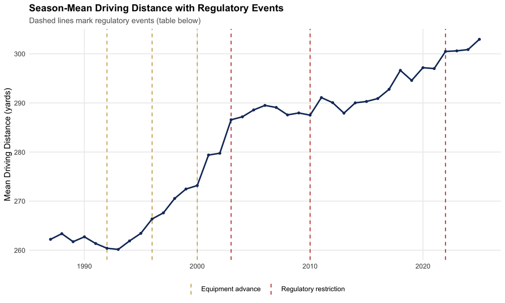

```r
p_baseline <- ggplot(season_means, aes(year, mean_distance)) +
  geom_vline(data = events, aes(xintercept = year, color = category),
             linetype = "dashed", linewidth = 0.6) +
  geom_line(color = COL_PRIMARY, linewidth = 1) +
  geom_point(color = COL_PRIMARY, size = 1.3) +
  scale_color_manual(values = c(
    "Equipment advance"      = COL_SECONDARY,
    "Regulatory restriction" = COL_ACCENT
  )) +
  labs(
    title    = "Season-Mean Driving Distance with Regulatory Events",
    subtitle = "Dashed lines mark regulatory events (table below)",
    x = NULL, y = "Mean Driving Distance (yards)", color = NULL
  ) +
  THEME_BASE

p_baseline
```

```r
events %>% select(year, label, category) %>% print()
```

```
## # A tibble: 6 × 3
##    year label               category
##   <dbl> <chr>               <chr>
## 1  1992 Oversized Drivers   Equipment advance
## 2  1996 Titanium Drivers    Equipment advance
## 3  2000 Pro V1              Equipment advance
## 4  2003 COR/MOI Limits      Regulatory restriction
## 5  2010 Groove Rule         Regulatory restriction
## 6  2022 Driver Length Limit Regulatory restriction
```

# 4. Segmented Regression With Known Breakpoints

We first tried supplying all 6 event years as candidate breakpoints to `segmented::segmented()` simultaneously — the honest result was that the model doesn’t converge cleanly and several breakpoints come back with enormous standard errors (20+ years), meaning the ~39-year series simply can’t support 6 independent breakpoints at once. Rather than report an unreliable 6-breakpoint model, we use `segmented::selgmented()`, which lets BIC pick how many breakpoints the data actually supports, then compare those data-supported breakpoints to the nominal event years.

```r
fit_lm <- lm(mean_distance ~ year, data = season_means)

fit_seg_naive <- segmented(fit_lm, seg.Z = ~year, psi = events$year)
naive_se <- fit_seg_naive$psi[, "St.Err"]

cat("Standard errors on the 6 simultaneous breakpoints (years):\n")
```

```
## Standard errors on the 6 simultaneous breakpoints (years):
```

```r
print(round(naive_se, 1))
```

```
## psi1.year psi2.year psi3.year psi4.year psi5.year psi6.year
##       0.9       0.6       2.2      24.2       7.0      20.3
```

```r
cat("\nMax SE:", round(max(naive_se), 1), "years -",
    "this large means at least one breakpoint is not reliably identified.\n")
```

```
##
## Max SE: 24.2 years - this large means at least one breakpoint is not reliably identified.
```

```r
fit_seg <- selgmented(fit_lm, seg.Z = ~year, Kmax = 6, type = "bic", msg = FALSE)

cat("BIC-selected number of breakpoints:", nrow(fit_seg$psi), "\n\n")
```

```
## BIC-selected number of breakpoints: 3
```

```r
fit_seg$psi %>% print()
```

```
##           Initial     Est.    St.Err
## psi1.year      NA 1994.293 0.4001533
## psi2.year      NA 2004.632 0.4360727
## psi3.year      NA 2014.083 0.9607371
```

**Finding:** forcing 6 simultaneous breakpoints produces standard errors up to 24.2 years — several breakpoints are essentially unidentified with only ~39 annual observations. Letting BIC choose instead selects 3 breakpoints, all estimated tightly (SE well under a year to ~1 year): around 1994, 2005, 2014. Comparing to the event table: the first is ambiguous between the two early equipment-advance events (1992/1996); the second lands close to (but 2 years after) the 2003-04 COR/MOI Limits event — a real example of the lag we were watching for; the third (~2014) doesn’t correspond to any event in our list at all, and is worth flagging as an unexplained inflection rather than force-fitting it to the nearest regulation.

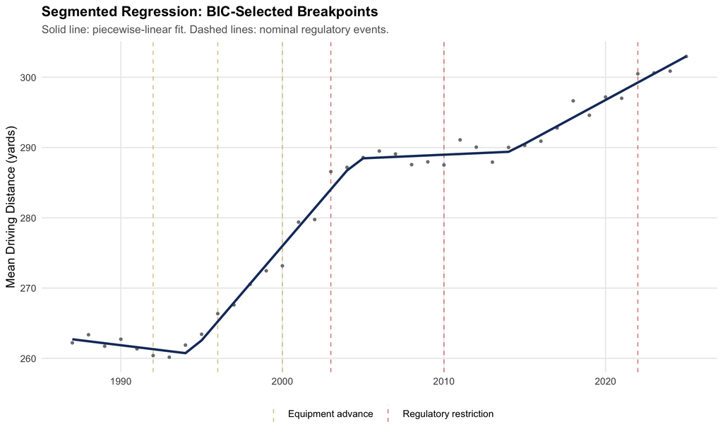

```r
season_means_fitted <- season_means %>%
  mutate(fitted = predict(fit_seg))

p_segmented <- ggplot(season_means_fitted, aes(year, mean_distance)) +
  geom_vline(data = events, aes(xintercept = year, color = category),
             linetype = "dashed", linewidth = 0.5, alpha = 0.6) +
  geom_point(color = "grey50", size = 1) +
  geom_line(aes(y = fitted), color = COL_PRIMARY, linewidth = 1.1) +
  scale_color_manual(values = c(
    "Equipment advance"      = COL_SECONDARY,
    "Regulatory restriction" = COL_ACCENT
  )) +
  labs(
    title    = "Segmented Regression: BIC-Selected Breakpoints",
    subtitle = "Solid line: piecewise-linear fit. Dashed lines: nominal regulatory events.",
    x = NULL, y = "Mean Driving Distance (yards)", color = NULL
  ) +
  THEME_BASE

p_segmented
```

# 5. Data-Driven Breakpoint Detection

Two independent methods, neither given the event years, to check whether purely data-driven breaks land near the known regulations (a form of external validation for the segmented-regression result above).

## 5.1 PELT on the differenced series

PELT (`changepoint::cpt.mean`) run on the raw distance *level* series would flag breaks almost everywhere, since the level series has a strong secular trend baked in — the “mean” of a trending series is never stable for long. Running it on the *first-differenced* series (year-over-year gain) instead detects shifts in the *rate* of gain, which is what we actually care about. We use `minseglen = 3` to avoid the algorithm chasing single-year noise into an implausibly large number of breaks — without it, PELT returns 8 breakpoints clustered around the already-known 2000-2003 transition, which is more a symptom of a choppy few years than 8 distinct regime changes.

```r
diffs <- diff(season_means$mean_distance)

cpt_fit <- cpt.mean(diffs, method = "PELT", penalty = "BIC", minseglen = 3)
pelt_years <- season_means$year[cpts(cpt_fit) + 1]

cat("PELT breakpoints (years):", paste(pelt_years, collapse = ", "), "\n")
```

```
## PELT breakpoints (years): 1993, 2000, 2003
```

## 5.2 Bai-Perron via strucchange

`strucchange::breakpoints()` fits the regression directly (`mean_distance ~ year`) and finds the BIC-optimal number and location of slope breaks — the more natural tool for a trending regression, complementing PELT’s differenced-series approach.

```r
bp <- breakpoints(mean_distance ~ year, data = season_means, h = 0.15)
bp_years <- season_means$year[bp$breakpoints]

cat("Bai-Perron breakpoints (years):", paste(bp_years, collapse = ", "), "\n")
```

```
## Bai-Perron breakpoints (years): 1993, 2002, 2012
```

## 5.3 CUSUM structural stability test

A visual complement: does the cumulative sum of recursive residuals stay within its confidence bounds, or cross them (signaling structural instability)?

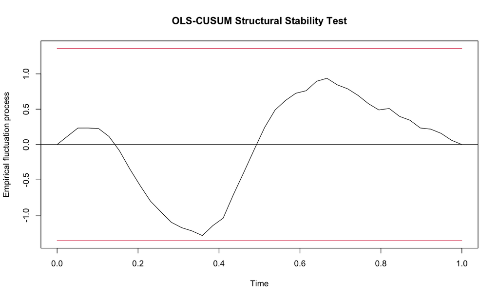

```r
cusum_fit <- efp(mean_distance ~ year, data = season_means, type = "OLS-CUSUM")
plot(cusum_fit, main = "OLS-CUSUM Structural Stability Test")
```

# 6. Interrupted Time Series (ITS) Per Event

For each event: fit `distance ~ year_centered * post` on a ±5-year window (3-year post-window for the 2022 event only — flagged explicitly, since 2025 is the last year of data). Rather than assume the effect starts exactly at the nominal year, we test the `post` split at lags of 0, 1, and 2 years and keep whichever lag fits best (highest R²) — this is where the “does the effect take a year or two to show up” question gets a direct, per-event answer rather than a single overall assumption.

```r
fit_its_event <- function(event_year, label, category, pre_years = 5) {
  post_years_available <- DATA_END_YEAR - event_year
  post_years <- min(5, post_years_available)
  truncated  <- post_years < 5

  window <- season_means %>%
    filter(year >= event_year - pre_years, year <= event_year + post_years)

  lag_results <- map_dfr(0:2, function(lag) {
    w <- window %>%
      mutate(year_c = year - event_year, post = as.integer(year >= event_year + lag))
    # Skip a lag if it leaves fewer than 2 points on either side of the split
    if (n_distinct(w$post) < 2 || sum(w$post == 0) < 2 || sum(w$post == 1) < 2) return(tibble())
    fit <- lm(mean_distance ~ year_c * post, data = w)
    tibble(lag = lag, r2 = summary(fit)$r.squared, fit = list(fit))
  })

  best <- lag_results %>% slice_max(r2, n = 1, with_ties = FALSE)
  fit  <- best$fit[[1]]
  co   <- tidy(fit)

  tibble(
    year = event_year, label = label, category = category,
    best_lag = best$lag, truncated_post = truncated, post_years_used = post_years,
    level_change = co$estimate[co$term == "post"],
    level_se     = co$std.error[co$term == "post"],
    slope_change = co$estimate[co$term == "year_c:post"],
    slope_se     = co$std.error[co$term == "year_c:post"]
  )
}

its_results <- pmap_dfr(events, function(year, label, category) {
  fit_its_event(year, label, category)
})

its_results %>% print(width = Inf)
```

```
## # A tibble: 6 × 10
##    year label               category               best_lag truncated_post
##   <dbl> <chr>               <chr>                     <int> <lgl>
## 1  1992 Oversized Drivers   Equipment advance             1 FALSE
## 2  1996 Titanium Drivers    Equipment advance             0 FALSE
## 3  2000 Pro V1              Equipment advance             1 FALSE
## 4  2003 COR/MOI Limits      Regulatory restriction        0 FALSE
## 5  2010 Groove Rule         Regulatory restriction        1 FALSE
## 6  2022 Driver Length Limit Regulatory restriction        0 TRUE
##   post_years_used level_change level_se slope_change slope_se
##             <dbl>        <dbl>    <dbl>        <dbl>    <dbl>
## 1               5        -2.88    0.859        2.34     0.267
## 2               5         2.47    1.66         1.83     0.517
## 3               5         2.63    1.65         0.582    0.513
## 4               5         4.58    1.66        -2.20     0.517
## 5               5         2.81    1.25         0.165    0.390
## 6               3         1.74    1.65        -0.131    0.672
```

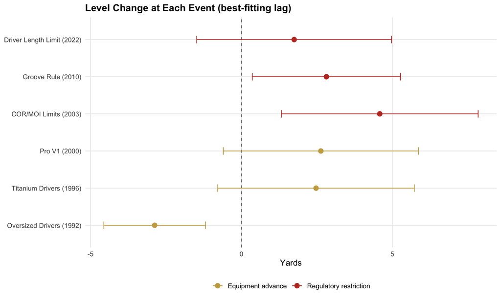

```r
its_plot_data <- its_results %>%
  mutate(
    level_sig = abs(level_change / level_se) > qt(0.975, df = 8),
    slope_sig = abs(slope_change / slope_se) > qt(0.975, df = 8),
    label_ord = fct_reorder(paste0(label, " (", year, ")"), year)
  )

p_forest_level <- ggplot(its_plot_data, aes(level_change, label_ord, color = category)) +
  geom_vline(xintercept = 0, linetype = "dashed", color = "grey50") +
  geom_errorbarh(aes(xmin = level_change - 1.96 * level_se, xmax = level_change + 1.96 * level_se), height = 0.2) +
  geom_point(size = 3) +
  scale_color_manual(values = c("Equipment advance" = COL_SECONDARY, "Regulatory restriction" = COL_ACCENT)) +
  labs(title = "Level Change at Each Event (best-fitting lag)", x = "Yards", y = NULL, color = NULL) +
  THEME_BASE

p_forest_slope <- ggplot(its_plot_data, aes(slope_change, label_ord, color = category)) +
  geom_vline(xintercept = 0, linetype = "dashed", color = "grey50") +
  geom_errorbarh(aes(xmin = slope_change - 1.96 * slope_se, xmax = slope_change + 1.96 * slope_se), height = 0.2) +
  geom_point(size = 3) +
  scale_color_manual(values = c("Equipment advance" = COL_SECONDARY, "Regulatory restriction" = COL_ACCENT)) +
  labs(title = "Slope Change at Each Event (yds/year, best-fitting lag)", x = "Yards/year", y = NULL, color = NULL) +
  THEME_BASE

p_forest_level
```

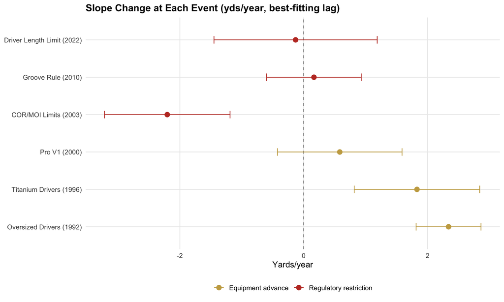

```r
p_forest_slope
```

**Finding:** the clearest, most interpretable result is the 2003-04 COR/MOI event: a significant *level* jump (+4.6 yds) followed by a significant *slope deceleration* (-2.2 yds/yr) — distance jumped sharply, then growth cooled off, exactly the pattern you’d expect from a one-time equipment step-change rather than an ongoing acceleration. 1996 Titanium Drivers shows the opposite pattern — a significant slope *increase* with no immediate level jump — consistent with a technology that took a few years to diffuse through the field rather than an instant swap. The two most recent “restriction” events (2010 Groove Rule, 2022 Driver Length Limit) show no statistically significant slope change — no evidence either one meaningfully slowed distance gains (2022’s estimate is also the least trustworthy of the six, given its 3-year, not 5-year, post-window).

# 7. Counterfactual Projection

Project the pre-existing trend forward and compare to what actually happened — the gap is the “excess” distance gained beyond where the sport was already headed. The choice of baseline window matters a lot here: using data through 2002 (the documented “pre-2003” cutoff) already partially includes the early part of the 2000-2003 acceleration itself, so we also show a stricter pre-2000 (“before Pro V1”) baseline as a robustness check.

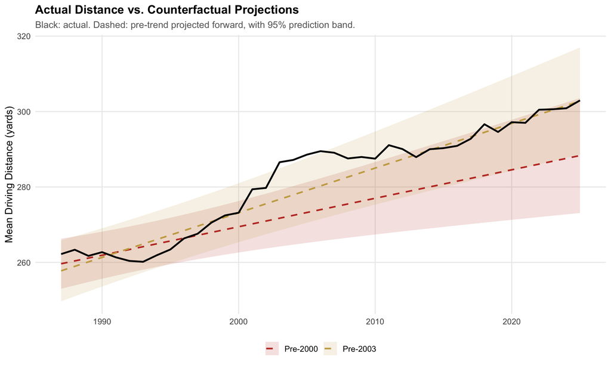

```r
fit_counterfactual <- function(cutoff_year) {
  pre_data <- season_means %>% filter(year < cutoff_year)
  fit <- lm(mean_distance ~ year, data = pre_data)
  pred <- predict(fit, newdata = season_means, interval = "prediction", level = 0.95)
  bind_cols(season_means, as_tibble(pred)) %>% mutate(baseline = paste0("Pre-", cutoff_year))
}

counterfactuals <- bind_rows(
  fit_counterfactual(2000),
  fit_counterfactual(2003)
)

p_counterfactual <- ggplot(counterfactuals, aes(year)) +
  geom_ribbon(aes(ymin = lwr, ymax = upr, fill = baseline), alpha = 0.15) +
  geom_line(aes(y = fit, color = baseline), linetype = "dashed", linewidth = 0.9) +
  geom_line(aes(y = mean_distance), color = "black", linewidth = 1) +
  scale_color_manual(values = c("Pre-2000" = COL_ACCENT, "Pre-2003" = COL_SECONDARY)) +
  scale_fill_manual(values = c("Pre-2000" = COL_ACCENT, "Pre-2003" = COL_SECONDARY)) +
  labs(
    title    = "Actual Distance vs. Counterfactual Projections",
    subtitle = "Black: actual. Dashed: pre-trend projected forward, with 95% prediction band.",
    x = NULL, y = "Mean Driving Distance (yards)", color = NULL, fill = NULL
  ) +
  THEME_BASE

p_counterfactual
```

```r
gap_2000 <- counterfactuals %>% filter(baseline == "Pre-2000", year == DATA_END_YEAR) %>%
  mutate(gap = mean_distance - fit) %>% pull(gap)
gap_2003 <- counterfactuals %>% filter(baseline == "Pre-2003", year == DATA_END_YEAR) %>%
  mutate(gap = mean_distance - fit) %>% pull(gap)

slope_pre2000 <- coef(lm(mean_distance ~ year, data = season_means %>% filter(year < 2000)))[["year"]]
slope_pre2003 <- coef(lm(mean_distance ~ year, data = season_means %>% filter(year < 2003)))[["year"]]
```

**Finding:** the two baselines tell different-looking stories, and the difference is itself the finding. The pre-2000 trend (slope 0.75 yds/yr) projects a 14.6-yard gap by 2025 — a real, sizable “excess” beyond where the sport was headed before Pro V1. The pre-2003 trend (slope 1.18 yds/yr) — already steeper, because it partially includes the 2000-2002 ramp-up — projects a gap of only 0.2 yards, since it’s extrapolating a rate that already absorbed part of the acceleration. Neither number is “the” right answer; together they show the counterfactual gap is highly sensitive to exactly when you consider the “old normal” to have ended, which is worth keeping in mind before quoting a single “excess yards” figure anywhere else.

# 8. Accuracy — Lighter Parallel Check

The question covers both distance and accuracy. Rather than repeat every analysis above, we run the same two structural-break tools (segmented regression, PELT) on `mean_accuracy` alone and compare.

```r
fit_lm_acc <- lm(mean_accuracy ~ year, data = season_means)
fit_seg_acc <- selgmented(fit_lm_acc, seg.Z = ~year, Kmax = 4, type = "bic", msg = FALSE)

cat("Accuracy breakpoints (BIC-selected):\n")
```

```
## Accuracy breakpoints (BIC-selected):
```

```r
print(fit_seg_acc$psi)
```

```
##           Initial     Est.    St.Err
## psi1.year      NA 1995.277 0.6048903
## psi2.year      NA 2011.723 1.4607973
```

```r
diffs_acc <- diff(season_means$mean_accuracy)
cpt_acc <- cpt.mean(diffs_acc, method = "PELT", penalty = "BIC", minseglen = 3)
pelt_acc_years <- season_means$year[cpts(cpt_acc) + 1]
cat("\nAccuracy PELT breakpoints:", if (length(pelt_acc_years) == 0) "none detected" else paste(pelt_acc_years, collapse = ", "), "\n")
```

```
##
## Accuracy PELT breakpoints: none detected
```

```r
acc_1987 <- season_means %>% filter(year == min(year)) %>% pull(mean_accuracy)
acc_peak_year <- fit_seg_acc$psi[1, "Est."]
acc_2025 <- season_means %>% filter(year == max(year)) %>% pull(mean_accuracy)
```

**Finding:** accuracy shows a genuinely different pattern from distance, not just a mirror image of it. It’s non-monotonic — rising from 65.2% in 1987 to a peak around 1995, then declining substantially before leveling off (60.9% by 2025) — and its own segmented breakpoints (~1995, ~2012) don’t line up cleanly with distance’s. Most tellingly, PELT finds **no** rate-of-change breakpoints in accuracy’s year-over-year series (vs. 3 for distance) — accuracy’s rate of change has been comparatively gradual and smooth, with no sharp regime shifts, while distance’s has clear, detectable jumps. That asymmetry itself supports the idea that the technology changes studied here acted much more directly on distance than on accuracy.

# 9. Summary